## Introduction

Research on human activity recognition research focuses to identify trend and health information from different activities. People take their daily exercise using different exercise tools in order to improve their health. Devices such as Jawbone Up, Nike FuelBand, and Fitbit can be used for collecting large amount of data from an individual while doing exercise. Further analysis of this large amount of data can tell about the personal activity of an individual with a small cost. Usually enthusiastic individuals use these devices to follow up their health improvement. Further information for instance behavior analysis of the individual can also be measured from this data set. Previous data shows that people regularly measure how much particular they do. In this project, we have used data from accelerometers on the belt, forearm, arm, and dumbell of 6 participants. These participants were asked to perform barbell lifts correctly and incorrectly in 5 different ways. Details of this data can be found at the website:

http://groupware.les.inf.puc-rio.br/har.

## Given Data Set

The training data for this project are available in the following links and I downloaded them in my working directory:

https://d396qusza40orc.cloudfront.net/predmachlearn/pml-training.csv

The test data are available here:

https://d396qusza40orc.cloudfront.net/predmachlearn/pml-testing.csv

## Goal of this project

Goal of this project is to create a prediction model to understand how the participants did the exercise. In this predictor model, performance of individual’s assigned exercises participated by six participants will be predict. This is the classe variable of the training set, which classifies the correct and incorrect outcomes into A, B, C, D, and E categories. Exercises are classified as: exactly according to the specification (Class A), throwing the elbows to the front (Class B), lifting the dumbbell only halfway (Class C), lowering the dumbbell only halfway (Class D) and throwing the hips to the front (Class E). After this exercise we have to made a report that describes how the model for the project was built, its cross validation, expected out of sample error calculation, and the choices made.

## Github Link

My github link is: https://github.com/sarwar-rcc/practicalmachinelearning

## rPub Link

http://rpubs.com/msjmo/158809

## Details Steps of Predictor

```r
# Load the file
setwd("D:/PhD/corsera/Machine Learning/Assignments")
trainingData = read.csv("pml-training.csv", na.strings=c("", "NA", "NULL"))
testingData = read.csv("pml-testing.csv", na.strings=c("", "NA", "NULL"))
```

```r
# We take a quick look at the data and particularly at classe which is the variable we need to predict:
str(trainingData, list.len=15)
```

```
## 'data.frame':    19622 obs. of  160 variables:
##  $ X                       : int  1 2 3 4 5 6 7 8 9 10 ...
##  $ user_name               : Factor w/ 6 levels "adelmo","carlitos",..: 2 2 2 2 2 2 2 2 2 2 ...
##  $ raw_timestamp_part_1    : int  1323084231 1323084231 1323084231 1323084232 1323084232 1323084232 1323084232 1323084232 1323084232 1323084232 ...
##  $ raw_timestamp_part_2    : int  788290 808298 820366 120339 196328 304277 368296 440390 484323 484434 ...
##  $ cvtd_timestamp          : Factor w/ 20 levels "02/12/2011 13:32",..: 9 9 9 9 9 9 9 9 9 9 ...
##  $ new_window              : Factor w/ 2 levels "no","yes": 1 1 1 1 1 1 1 1 1 1 ...
##  $ num_window              : int  11 11 11 12 12 12 12 12 12 12 ...
##  $ roll_belt               : num  1.41 1.41 1.42 1.48 1.48 1.45 1.42 1.42 1.43 1.45 ...
##  $ pitch_belt              : num  8.07 8.07 8.07 8.05 8.07 8.06 8.09 8.13 8.16 8.17 ...
##  $ yaw_belt                : num  -94.4 -94.4 -94.4 -94.4 -94.4 -94.4 -94.4 -94.4 -94.4 -94.4 ...
##  $ total_accel_belt        : int  3 3 3 3 3 3 3 3 3 3 ...
##  $ kurtosis_roll_belt      : Factor w/ 396 levels "-0.016850","-0.021024",..: NA NA NA NA NA NA NA NA NA NA ...
##  $ kurtosis_picth_belt     : Factor w/ 316 levels "-0.021887","-0.060755",..: NA NA NA NA NA NA NA NA NA NA ...
##  $ kurtosis_yaw_belt       : Factor w/ 1 level "#DIV/0!": NA NA NA NA NA NA NA NA NA NA ...
##  $ skewness_roll_belt      : Factor w/ 394 levels "-0.003095","-0.010002",..: NA NA NA NA NA NA NA NA NA NA ...
##   [list output truncated]
```

```r
table(trainingData$classe)
```

```
##
##    A    B    C    D    E
## 5580 3797 3422 3216 3607
```

```r
prop.table(table(trainingData$user_name, trainingData$classe), 1)
```

```
##
##                    A         B         C         D         E
##   adelmo   0.2993320 0.1993834 0.1927030 0.1323227 0.1762590
##   carlitos 0.2679949 0.2217224 0.1584190 0.1561697 0.1956941
##   charles  0.2542421 0.2106900 0.1524321 0.1815611 0.2010747
##   eurico   0.2817590 0.1928339 0.1592834 0.1895765 0.1765472
##   jeremy   0.3459730 0.1437390 0.1916520 0.1534392 0.1651969
##   pedro    0.2452107 0.1934866 0.1911877 0.1796935 0.1904215
```

```r
prop.table(table(trainingData$classe))
```

```
##
##         A         B         C         D         E
## 0.2843747 0.1935073 0.1743961 0.1638977 0.1838243
```

```r
dim(trainingData)
```

```
## [1] 19622   160
```

```r
dim(testingData)
```

```
## [1]  20 160
```

```r
train.dena<-trainingData[,colSums(is.na(trainingData)) == 0]
dim(train.dena)
```

```
## [1] 19622    60
```

```r
 remove = c('X', 'user_name', 'raw_timestamp_part_1', 'raw_timestamp_part_2', 'cvtd_timestamp', 'new_window', 'num_window')
```

```r
train.dare <- train.dena[,-which(names(train.dena) %in% remove)]
```

```r
 dim(train.dare)
```

```
## [1] 19622    53
```

```r
 library(lattice)
library(ggplot2)
library(caret)
zeroVar= nearZeroVar(train.dare[sapply(train.dare, is.numeric)], saveMetrics = TRUE)
train.nonzerovar = train.dare[,zeroVar[, 'nzv']==0]
dim(train.nonzerovar)
```

```
## [1] 19622    53
```

```r
corrMatrix <- cor(na.omit(train.nonzerovar[sapply(train.nonzerovar, is.numeric)]))
dim(corrMatrix)
```

```
## [1] 52 52
```

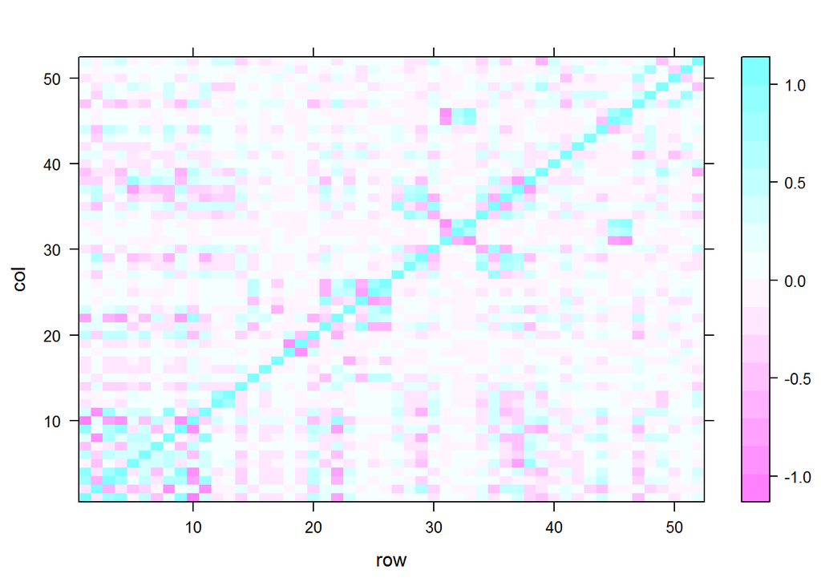

```r
corrDF <- expand.grid(row = 1:52, col = 1:52)
corrDF$correlation <- as.vector(corrMatrix)
levelplot(correlation ~ row+ col, corrDF)
```

```r
removecor = findCorrelation(corrMatrix, cutoff = .90, verbose = TRUE)
```

```
## Compare row 10  and column  1 with corr  0.992
##   Means:  0.27 vs 0.168 so flagging column 10
## Compare row 1  and column  9 with corr  0.925
##   Means:  0.25 vs 0.164 so flagging column 1
## Compare row 9  and column  4 with corr  0.928
##   Means:  0.233 vs 0.161 so flagging column 9
## Compare row 8  and column  2 with corr  0.966
##   Means:  0.245 vs 0.157 so flagging column 8
## Compare row 19  and column  18 with corr  0.918
##   Means:  0.091 vs 0.158 so flagging column 18
## Compare row 46  and column  31 with corr  0.914
##   Means:  0.101 vs 0.161 so flagging column 31
## Compare row 46  and column  33 with corr  0.933
##   Means:  0.083 vs 0.164 so flagging column 33
## All correlations <= 0.9
```

```r
train.decor = train.nonzerovar[,-removecor]
dim(train.decor)
```

```
## [1] 19622    46
```

```r
inTrain <- createDataPartition(y=train.decor$classe, p=0.7, list=FALSE)
train <- train.decor[inTrain,]; testing <- train.decor[-inTrain,]
dim(train);
```

```
## [1] 13737    46
```

```r
dim(testing)
```

```
## [1] 5885   46
```

```r
library(tree)
set.seed(12345)
tree.train=tree(classe~.,data=train)
summary(tree.train)
```

```
##
## Classification tree:
## tree(formula = classe ~ ., data = train)
## Variables actually used in tree construction:
##  [1] "pitch_forearm"     "magnet_belt_y"     "accel_forearm_z"
##  [4] "magnet_dumbbell_y" "roll_forearm"      "magnet_dumbbell_z"
##  [7] "pitch_belt"        "yaw_belt"          "accel_forearm_x"
## [10] "accel_dumbbell_y"  "accel_dumbbell_z"  "magnet_arm_x"
## Number of terminal nodes:  21
## Residual mean deviance:  1.652 = 22660 / 13720
## Misclassification error rate: 0.3295 = 4527 / 13737
```

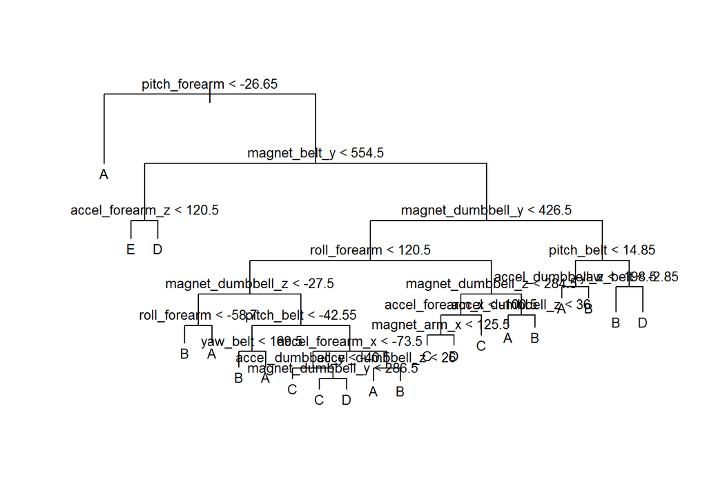

```r
plot(tree.train)
text(tree.train,pretty=0, cex =.8)
```

```r
library(caret)
modFit <- train(classe ~ .,method="rpart",data=train)
print(modFit$finalModel)
```

```
## n= 13737
##
## node), split, n, loss, yval, (yprob)
##       * denotes terminal node
##
##  1) root 13737 9831 A (0.28 0.19 0.17 0.16 0.18)
##    2) pitch_forearm< -26.65 1232   53 A (0.96 0.043 0 0 0) *
##    3) pitch_forearm>=-26.65 12505 9778 A (0.22 0.21 0.19 0.18 0.2)
##      6) magnet_belt_y>=555.5 11490 8765 A (0.24 0.23 0.21 0.18 0.15)
##       12) magnet_dumbbell_y< 426.5 9448 6798 A (0.28 0.18 0.24 0.17 0.13)
##         24) roll_forearm< 120.5 5882 3507 A (0.4 0.18 0.19 0.14 0.091) *
##         25) roll_forearm>=120.5 3566 2353 C (0.077 0.18 0.34 0.22 0.18)
##           50) accel_forearm_x>=-99.5 2443 1498 C (0.089 0.21 0.39 0.089 0.22) *
##           51) accel_forearm_x< -99.5 1123  545 D (0.051 0.093 0.24 0.51 0.1) *
##       13) magnet_dumbbell_y>=426.5 2042 1102 B (0.037 0.46 0.043 0.21 0.25) *
##      7) magnet_belt_y< 555.5 1015  192 E (0.002 0.003 0.00099 0.18 0.81) *
```

```r
library(rattle)
```

[figure not shown]

```r
fancyRpartPlot(modFit$finalModel)
```

```r
tree.pred=predict(tree.train,testing,type="class")
predMatrix = with(testing,table(tree.pred,classe))
sum(diag(predMatrix))/sum(as.vector(predMatrix))
```

```
## [1] 0.662192
```

```r
tree.pred=predict(modFit,testing)
predMatrix = with(testing,table(tree.pred,classe))
sum(diag(predMatrix))/sum(as.vector(predMatrix))
```

```
## [1] 0.4920986
```

```r
cv.train=cv.tree(tree.train,FUN=prune.misclass)
cv.train
```

```
## $size
##  [1] 21 20 19 18 17 16 13 12 10  7  5  1
##
## $dev
##  [1] 4507 4542 4571 4610 5129 5479 5539 5539 6069 6969 7231 9831
##
## $k
##  [1]     -Inf  36.0000  58.0000  74.0000 142.0000 151.0000 160.3333
##  [8] 163.0000 195.5000 229.6667 251.0000 654.2500
##
## $method
## [1] "misclass"
##
## attr(,"class")
## [1] "prune"         "tree.sequence"
```

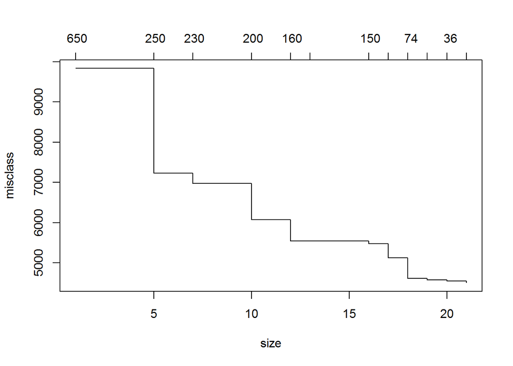

```r
plot(cv.train)
```

```r
prune.train=prune.misclass(tree.train,best=18)
tree.pred=predict(prune.train,testing,type="class")
predMatrix = with(testing,table(tree.pred,classe))
sum(diag(predMatrix))/sum(as.vector(predMatrix))
```

```
## [1] 0.6496177
```

## Data Manipulation

```r
require(randomForest)
set.seed(12345)
rf.train=randomForest(classe~.,data=train,ntree=100, importance=TRUE)
rf.train
```

```
##
## Call:
##  randomForest(formula = classe ~ ., data = train, ntree = 100,      importance = TRUE)
##                Type of random forest: classification
##                      Number of trees: 100
## No. of variables tried at each split: 6
##
##         OOB estimate of  error rate: 0.68%
## Confusion matrix:
##      A    B    C    D    E class.error
## A 3899    4    2    0    1 0.001792115
## B   24 2628    6    0    0 0.011286682
## C    0   17 2376    3    0 0.008347245
## D    0    0   21 2226    5 0.011545293
## E    0    1    2    7 2515 0.003960396
```

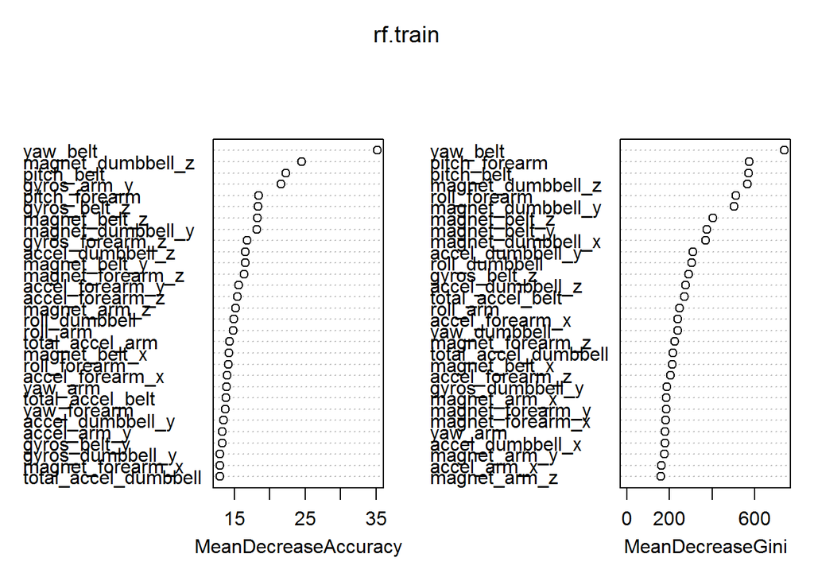

```r
varImpPlot(rf.train,)
```

```r
tree.pred=predict(rf.train,testing,type="class")
predMatrix = with(testing,table(tree.pred,classe))
sum(diag(predMatrix))/sum(as.vector(predMatrix))
```

```
## [1] 0.9928632
```

## Result of the Project Assignment

Finally prediction result of the project assignment is derived

```r
predictors <- predict(rf.train, testingData)
predictors
```

```
##  1  2  3  4  5  6  7  8  9 10 11 12 13 14 15 16 17 18 19 20
##  B  A  B  A  A  E  D  B  A  A  B  C  B  A  E  E  A  B  B  B
## Levels: A B C D E
```

## Conclusion

Since I am new in R and machine learning algorithms, I need more time to create a better predictor model.I took help from different prediction model available in online to have better understanding about the prediction model. And I hope I will do better in the next courses in this data science seriese.